# Homework 1

Aaron Melcher

2024-09-30

#[NYC Flights]

```r
library(nycflights13)
flights |> select(carrier, air_time, distance)
```

```
## # A tibble: 336,776 × 3
##    carrier air_time distance
##    <chr>      <dbl>    <dbl>
##  1 UA           227     1400
##  2 UA           227     1416
##  3 AA           160     1089
##  4 B6           183     1576
##  5 DL           116      762
##  6 UA           150      719
##  7 B6           158     1065
##  8 EV            53      229
##  9 B6           140      944
## 10 AA           138      733
## # ℹ 336,766 more rows
```

##Part A

```r
flights <- mutate(flights,
  speed = distance / air_time
)
flights
```

```
## # A tibble: 336,776 × 20
##     year month   day dep_time sched_dep_time dep_delay arr_time sched_arr_time
##    <int> <int> <int>    <int>          <int>     <dbl>    <int>          <int>
##  1  2013     1     1      517            515         2      830            819
##  2  2013     1     1      533            529         4      850            830
##  3  2013     1     1      542            540         2      923            850
##  4  2013     1     1      544            545        -1     1004           1022
##  5  2013     1     1      554            600        -6      812            837
##  6  2013     1     1      554            558        -4      740            728
##  7  2013     1     1      555            600        -5      913            854
##  8  2013     1     1      557            600        -3      709            723
##  9  2013     1     1      557            600        -3      838            846
## 10  2013     1     1      558            600        -2      753            745
## # ℹ 336,766 more rows
## # ℹ 12 more variables: arr_delay <dbl>, carrier <chr>, flight <int>,
## #   tailnum <chr>, origin <chr>, dest <chr>, air_time <dbl>, distance <dbl>,
## #   hour <dbl>, minute <dbl>, time_hour <dttm>, speed <dbl>
```

##Part B

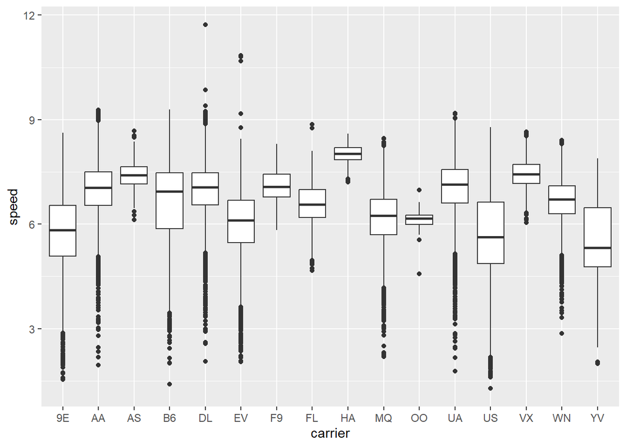

```r
ggplot(flights, aes(carrier, speed)) +
  geom_boxplot()
```

The boxplot above provides a very basic analysis of the average speed of each carrier. With this, we are able to see carrier ‘HA’ has the highest average speed of any of the carriers. Even though some of the carriers do have higher ‘highs’, HA still on average is faster than the others.

#[London Olympics]

```r
olympics <- read_csv("https://uwmadison.box.com/shared/static/rzw8h2x6dp5693gdbpgxaf2koqijo12l.csv")
```

##Part A/B

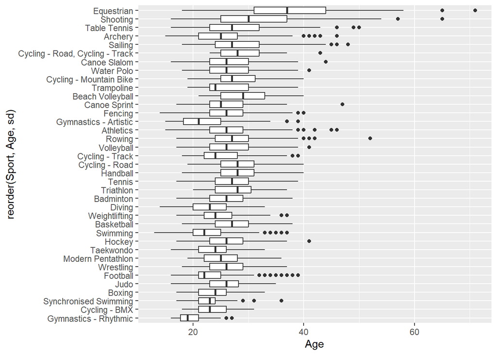

```r
counts <- olympics |>
  count(Sport)

olympics |>
  left_join(counts) |>
  filter(n > 5) |>
  ggplot() +
  geom_boxplot(
    aes(Age, reorder(Sport, Age, sd))
  )
```

##Part C

Average height(cm) among sports. See if there’s a noticeable difference in the height among athletes that participate in different sports. Following the same idea as the age distribution, I created a visualization on based on height.

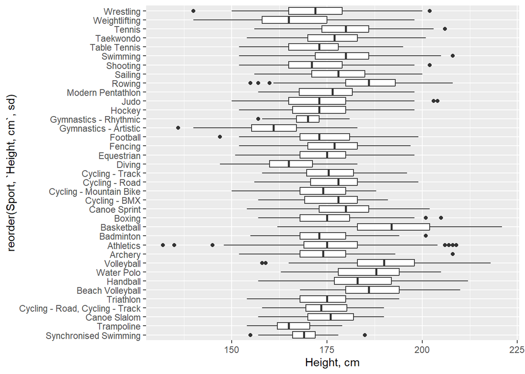

```r
olympics |>
  left_join(counts) |>
  filter(n > 5) |>
  ggplot() +
  geom_boxplot(
    aes(`Height, cm`, reorder(Sport, `Height, cm`, sd))
  )
```

#[Pokemon]

```r
pokemon <- read_csv("https://uwmadison.box.com/shared/static/hf5cmx3ew3ch0v6t0c2x56838er1lt2c.csv")
```

##Part A

```r
pokemon <- mutate(
  pokemon,
  'attack-to-defense' = Attack / Defense
)
pokemon |> select('attack-to-defense')
```

```
## # A tibble: 800 × 1
##    `attack-to-defense`
##                  <dbl>
##  1               1
##  2               0.984
##  3               0.988
##  4               0.813
##  5               1.21
##  6               1.10
##  7               1.08
##  8               1.17
##  9               1.33
## 10               0.738
## # ℹ 790 more rows
```

##Part B

```r
pokemon <- pokemon |>
  group_by(type_1) |>
  mutate(`attack-to-defense-median` = median(`attack-to-defense`, na.rm = TRUE)) |>
  ungroup()
pokemon
```

```
## # A tibble: 800 × 14
##    Name      type_1 type_2 Total    HP Attack Defense speed_attack speed_defense
##    <chr>     <chr>  <chr>  <dbl> <dbl>  <dbl>   <dbl>        <dbl>         <dbl>
##  1 Bulbasaur Grass  Poison   318    45     49      49           65            65
##  2 Ivysaur   Grass  Poison   405    60     62      63           80            80
##  3 Venusaur  Grass  Poison   525    80     82      83          100           100
##  4 Venusaur… Grass  Poison   625    80    100     123          122           120
##  5 Charmand… Fire   <NA>     309    39     52      43           60            50
##  6 Charmele… Fire   <NA>     405    58     64      58           80            65
##  7 Charizard Fire   Flying   534    78     84      78          109            85
##  8 Charizar… Fire   Dragon   634    78    130     111          130            85
##  9 Charizar… Fire   Flying   634    78    104      78          159           115
## 10 Squirtle  Water  <NA>     314    44     48      65           50            64
## # ℹ 790 more rows
## # ℹ 5 more variables: Speed <dbl>, Generation <dbl>, Legendary <lgl>,
## #   `attack-to-defense` <dbl>, `attack-to-defense-median` <dbl>
```

##Part C

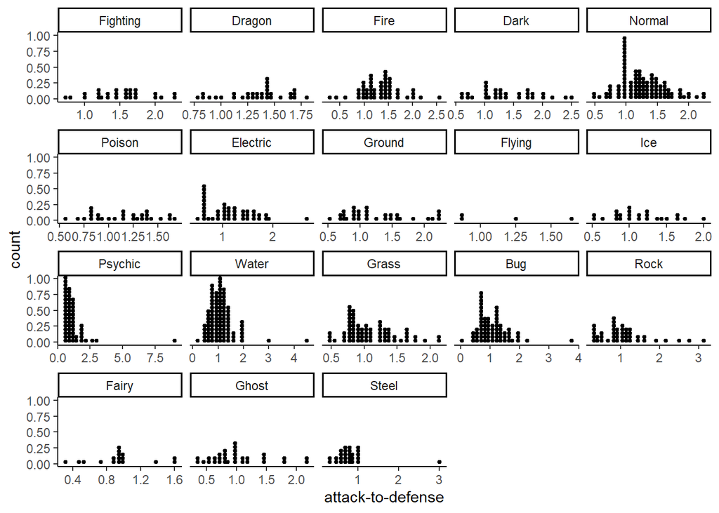

```r
pokemon$type_1 <- reorder(pokemon$type_1, desc(pokemon$`attack-to-defense-median`))

ggplot(
  pokemon,
  aes(`attack-to-defense`)
  ) +
  geom_dotplot() +
  facet_wrap("type_1", scales = "free_x") +
  theme_classic()
```

##Part D

An example dynamic plot could compare the stat totals of Pokemon based on different factors. For example, we could see the difference based on type or legendary status. This would answer how strong some types are or how strong legendary Pokemon are compared to regular Pokemon. The user would be able to select what facet they want to view and the query would update how the stat totals are shown.

#[Gene Expression Faceting]

```r
genes <- read_csv("https://uwmadison.box.com/shared/static/dwzchdtfca33r0f6i055k2d0939onnlv.csv")
head(genes, 3)
```

```
## # A tibble: 3 × 4
##   sample gene   time value
##    <dbl> <chr> <dbl> <dbl>
## 1      1 Pyy   0.677   103
## 2      1 Iapp  0.677     0
## 3      1 Chgb  0.677    86
```

##Part A

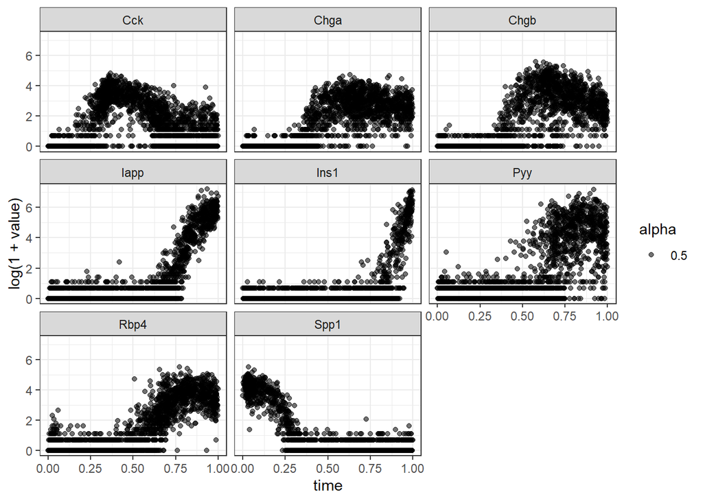

```r
genes <- mutate(genes,
                'log(1 + value)' = log(1 + value)
                )

ggplot(genes, aes(
  x = time,
  y = `log(1 + value)`,
  alpha = 0.5
)) +
  geom_point() +
  facet_wrap(~ gene) +
  theme_bw()
```

##Part B One advantage of small multiples is being able to compare multiple graphs one the same scale. This allows for comparisons between different facets such as shown in the graph above.

One disadvantage of small multiples is trying to display large amounts of data since too many graphs can be overwhelming and unweildy with lots of different information.

##Part C

```r
gene_groups <- genes |>
group_by(gene, rounded_time = round(time, 2)) |>
summarise(mean_value = mean(value))
head(gene_groups, 3)
```

```
## # A tibble: 3 × 3
## # Groups:   gene [1]
##   gene  rounded_time mean_value
##   <chr>        <dbl>      <dbl>
## 1 Cck           0        0
## 2 Cck           0.01     0
## 3 Cck           0.02     0.0652
```

##Part D

```r
fitted_values <- read_csv("https://go.wisc.edu/x678hu")
head(fitted_values, 3)
```

```
## # A tibble: 3 × 4
##   gene   time     mu sigma
##   <chr> <dbl>  <dbl> <dbl>
## 1 Pyy   0.677  52.8   3.17
## 2 Pyy   0.432   2.47  1.23
## 3 Pyy   0.749 112.    1.95
```

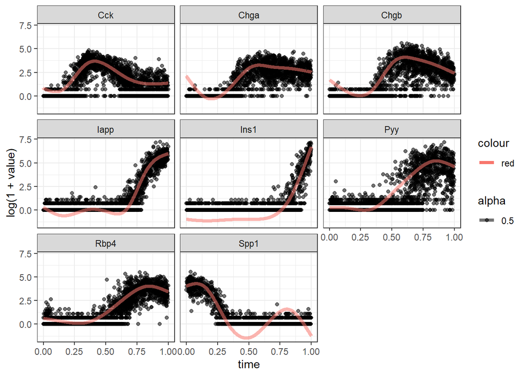

```r
ggplot(genes, aes(
  x = time,
  y = `log(1 + value)`,
  alpha = 0.5
)) +
  geom_point() +
  geom_line(
    data = fitted_values,
    aes(
      x = time,
      y = log(mu),
      color = 'red'
    ),
    size = 1.5
  ) +
  facet_wrap(~ gene) +
  theme_bw()
```

#[Visual Redesign]

##Part A Here is the code for a very basic visualization that was done in a past Stats class:

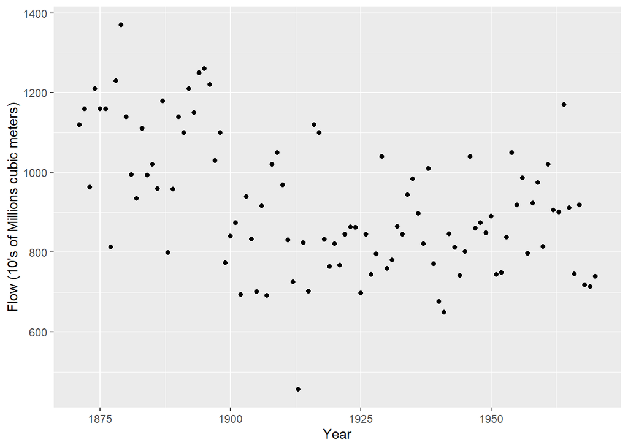

```r
n_df = read.csv("nile.csv")

ggplot(n_df) +
  geom_point(aes(
    x = Year,
    y = Flow
  )) +
  xlab("Year") +
  ylab("Flow (10's of Millions cubic meters)")
```

##Part B The main takeaways from the above graph are the overall decline in water flow over the time period. This is somewhat consistent from the visualization as there really isn’t an intended message and the interpretation of the data is left up to the viewer.

##Part C The visualization is legible but hard to draw any ideas from as there is any additional visualization provided to help highlight more information. The dataset itself isn’t super in-depth but additional visual elements can help with providing more in-depth analysis.

##Part D Here is a new visualization that uses the original design but adds a basic overlay to better highlight the information I want the viewer to know. With the limited data, there isn’t too much more that can be visualized.

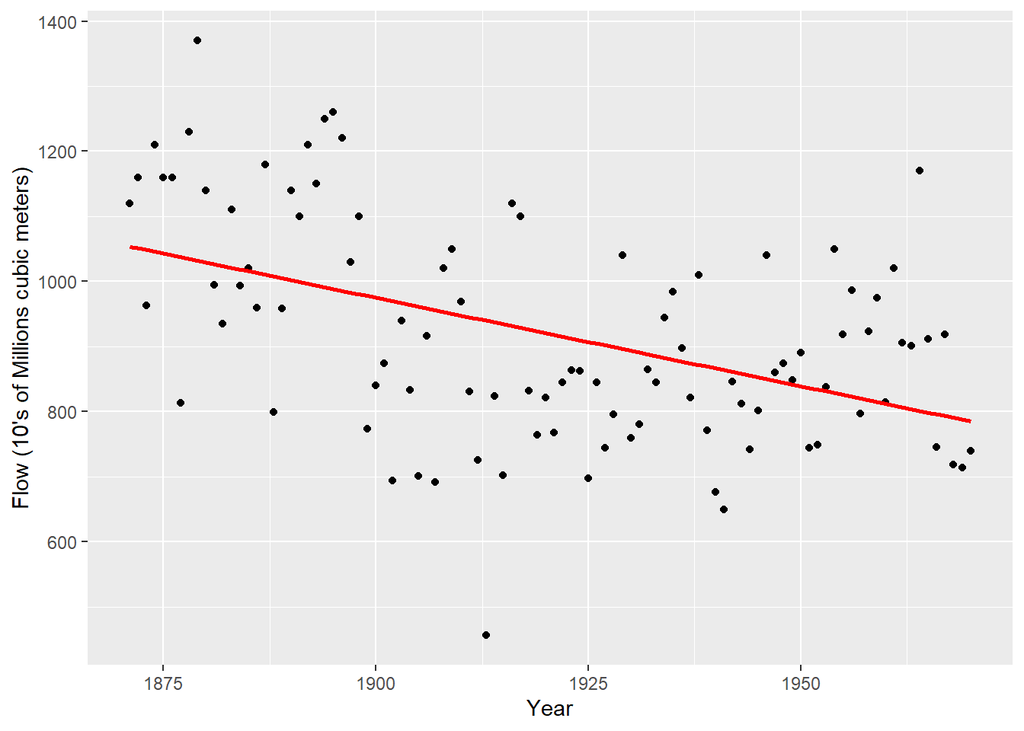

```r
ggplot(n_df,
       aes(
         x = Year,
         y = Flow)
       ) +
  geom_point() +
  geom_smooth(
    method = "lm",
    se = FALSE,
    color = "red",
    size = 1
    ) +
  xlab("Year") +
  ylab("Flow (10's of Millions cubic meters)")
```

#[California Wildfire Alternatives]

```r
fires <- read_csv("https://uwmadison.box.com/shared/static/k5vvekf1bhh9e16qb9s66owygc70t7dm.csv") |>
  select(Name, Counties, year, day_of_year, AcresBurned, MajorIncident)
head(fires, 3)
```

```
## # A tibble: 3 × 6
##   Name        Counties   year day_of_year AcresBurned MajorIncident
##   <chr>       <chr>     <dbl>       <dbl>       <dbl> <lgl>
## 1 Becks Fire  Lake       2013          22         296 FALSE
## 2 River Fire  Inyo       2013          55         406 TRUE
## 3 Jurupa Fire Riverside  2013          59         311 FALSE
```

##Part D

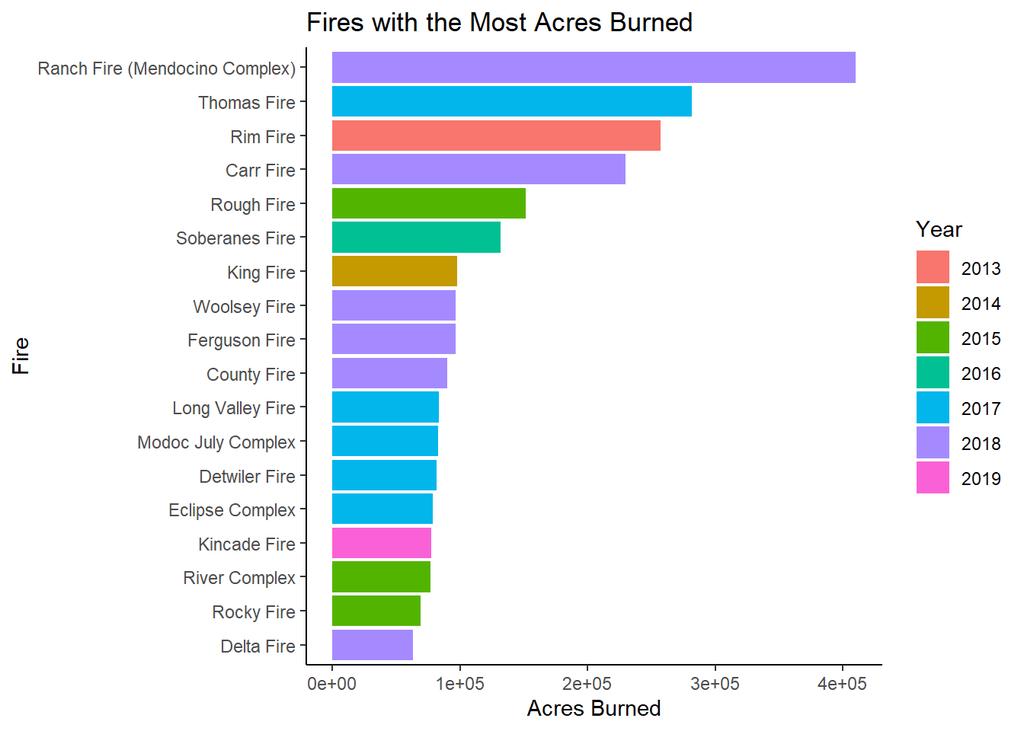

```r
fires$Name <- reorder(fires$Name, fires$AcresBurned)
top_fires <- fires |>
  top_n(18, AcresBurned)


ggplot(top_fires, aes(AcresBurned, Name, fill=factor(year))) +
  geom_bar(stat = 'identity') +
  labs(title = "Fires with the Most Acres Burned", x = "Acres Burned", y = "Fire", fill = "Year") +
  theme_classic()
```

#[Homelessness]

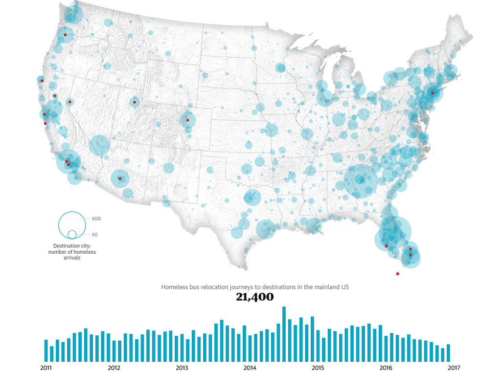

##Part A The data behind the graph would be the homeless bus relocations in the mainland United States over the period from 2011 to 2017. The rows would the year and the columns would the total number of homeless bus relocations to each city.

##Part B Both columns would be numeric types as we are tracking quantitative data and can count the total number of bus relocations.

##Part C The data would be encoded by city since each city is given a ‘circle’ mark to indicate how many people relocated to the city via bus during the time period. The marks would be derived from the number of relocations and the circles follow a exponential scale of the total number of relocations.

##Part D Yes since we are given a map of the US to show visually what cities were the most effected as well as a bar graph that gives a general overview of the change in number of bus relocations over the time period.